# Regresión Lineal Simple: Evaluación y Diagnóstico

Juan Barriola, Azul Villanueva y Franco Mastelli

03 de Septiembre de 2022

**Encuesta de Sueldos en el sector IT**

## Planteo del problema

El objetivo es crear un modelo lineal simple para explicar el sueldo bruto de los Data Analysts, Data Scientists y Data Engineers en Argentina.

La idea subyacente de cómo se puede explicar el salario bruto es:

$salarioBruto = \beta_0 +\beta_1X+\epsilon$

## Dataset y Modelos

```r
# Carga de librerías
library(tidyverse)
library(tidymodels)
```

En el notebook previo realizamos un análisis extenso de nuestro dataset, limpieza de los datos y algunos modelos para explicar el salario.

```r
# Cargamos el dataset limpio
encuesta_sueldos = read_csv("../Fuentes/regresion_simple/encuesta_ds_limpia.csv") %>%
                            mutate(id = 1:nrow(.)) # se agrega un ID
```

- **Modelo Edad**
- **Modelo Años de experiencia**
- **Modelo Años en la Empresa Actual**

Volvemos a realizar estos modelos:

```r
# Modelo Edad
modelo_edad = lm(formula = salario_bruto ~ edad, data = encuesta_sueldos)
# Modelo experiencia
modelo_experiencia = lm(formula = salario_bruto ~ anos_de_experiencia, data = encuesta_sueldos)
# Modelo empresa
modelo_empresa = lm(formula = salario_bruto ~ anos_en_la_empresa_actual, data = encuesta_sueldos)
```

En el notebook previo sólo habíamos interpretado el valor de los parámetros estimados. Ahora buscaremos responder preguntas tales como:

- ¿La relación entre la variable dependiente e independiente es estadísticamente significativa?
- ¿Qué proporción de la variabilidad logra explicar el modelo? ¿Cómo decidir que modelo explica mejor el fenómeno?
- ¿El modelo cumple con los supuestos del modelo lineal?

## Tidymodels: Broom

[Tidymodels](https://www.tidymodels.org/) es un meta-paquete (al igual que `tidyverse`) que contiene varios paquetes muy útiles para crear un framework para trabajar con modelos.

El paquete [broom](https://broom.tidymodels.org/) permite acceder a información de modelos e interactuar con los mismos de una manera sencilla. Las tres funciones para interactuar con los modelos son:

- `tidy()`: resume información sobre los componentes del modelo
- `glance()`: reporta información sobre todo el modelo
- `augment()`: agrega información de las observaciones según el modelo al dataset

Veremos cómo utilizar estas funciones con un modelo lineal

## Evaluación del modelo

La función `summary()` nos permite obtener mucha información sobre el modelo lineal:

```r
resumen_modelo_edad = summary(modelo_edad)
resumen_modelo_edad
```

```
##
## Call:
## lm(formula = salario_bruto ~ edad, data = encuesta_sueldos)
##
## Residuals:
##     Min      1Q  Median      3Q     Max
## -198889  -76530  -12184   54705  288688
##
## Coefficients:
##             Estimate Std. Error t value Pr(>|t|)
## (Intercept) 127645.9    27645.0   4.617 6.61e-06 ***
## edad          3217.9      857.9   3.751 0.000225 ***
## ---
## Signif. codes:  0 '***' 0.001 '**' 0.01 '*' 0.05 '.' 0.1 ' ' 1
##
## Residual standard error: 98020 on 220 degrees of freedom
## Multiple R-squared:  0.06011,    Adjusted R-squared:  0.05583
## F-statistic: 14.07 on 1 and 220 DF,  p-value: 0.0002254
```

Observamos que hay información sobre:

- Inferencia de $\beta_0$ y $\beta_1$
- Estimación de $\sigma^2$
- El coeficiente $R^2$
- Los residuos del modelo

En las secciones subsiguientes vamos a desarrollar cada uno de estos aspectos

### Inferencia de $\beta_1$ (test de significatividad individual)

En la salida de `summary()`, en la parte de **coefficients** observamos que están las columnas: estimate, std error, t value y Pr(>|t|). En las filas se encuentra el intercepto y la variable independiente: **edad**.

En el notebook anterior trabajamos sobre la interpretación del coeficiente estimado (estimate). Ahora nos focalizaremos en la columnas t value y Pr(>|t|).

En la inferencia de $\beta_1$ nos interesa responder si la relación entre la variable independiente y la variable a explicar es estadísticamente significativa. Nuestro test de hipótesis es:

$H_0 : \beta_1 = 0$

$H_1 : \beta_1 \neq 0$

El valor de **t value** nos indica el valor del estadístico T para este test.

El valor de **Pr(>|t|)** nos indica el p-valor para dicho test, acompañado de una ayuda visual sobre los niveles de significancia.

Como el p-valor es extremadamente pequeño concluimos que se rechaza la hipótesis nula, es decir, $\beta_1$ (parámetro poblacional) es distinto de cero.

Este test también se conoce como **test de significatividad individual** del parámetro.

#### Broom: tidy

Con la función `tidy()` del paquete broom podemos obtener la información sobre los parámetros como un dataframe:

```r
tidy(modelo_edad)
```

| term | estimate | std.error | statistic | p.value |
| --- | --- | --- | --- | --- |
| (Intercept) | 127645.906 | 27644.9933 | 4.617325 | 6.609470e-06 |
| edad | 3217.943 | 857.9263 | 3.750838 | 2.254099e-04 |

Tiene dos parámetros muy útiles:

- `conf.int`: valor lógico para incluir los intervalos de confianza o no
- `conf.level`: nivel de confianza para calcular los intervalos. Este valor es $1 - \alpha$

```r
# Incluimos intervalos de confianza
tidy(modelo_edad, conf.int = TRUE)
```

| term | estimate | std.error | statistic | p.value | conf.low | conf.high |
| --- | --- | --- | --- | --- | --- | --- |
| (Intercept) | 127645.906 | 27644.9933 | 4.617325 | 6.609470e-06 | 73162.998 | 182128.813 |
| edad | 3217.943 | 857.9263 | 3.750838 | 2.254099e-04 | 1527.137 | 4908.749 |

Al contar con los datos de los límites de los intervalos de confianza podemos chequear si los mismos contienen o no el cero

```r
# Aumentamos el nivel de confianza sobre los intervalos
tidy(modelo_edad, conf.int = TRUE, conf.level = 0.99)
```

| term | estimate | std.error | statistic | p.value | conf.low | conf.high |
| --- | --- | --- | --- | --- | --- | --- |
| (Intercept) | 127645.906 | 27644.9933 | 4.617325 | 6.609470e-06 | 55814.2351 | 199477.576 |
| edad | 3217.943 | 857.9263 | 3.750838 | 2.254099e-04 | 988.7404 | 5447.145 |

Al aumentar el nivel de confianza los intervalos se volvieron más anchos. De todas formas, el correspondiente a la edad sigue sin contener al cero.

Veamos los resultados para los otros dos modelos

**Modelo Años de experiencia**

```r
tidy(modelo_experiencia, conf.int = TRUE)
```

| term | estimate | std.error | statistic | p.value | conf.low | conf.high |
| --- | --- | --- | --- | --- | --- | --- |
| (Intercept) | 202389.926 | 7680.405 | 26.351467 | 5.381491e-70 | 187253.342 | 217526.510 |
| anos_de_experiencia | 6405.658 | 1082.571 | 5.917081 | 1.243747e-08 | 4272.122 | 8539.195 |

Al igual que en el modelo anterior el p-valor es muy pequeño y el intervalo no contiene al cero

**Modelo Años en la Empresa Actual**

```r
tidy(modelo_empresa, conf.int = TRUE)
```

| term | estimate | std.error | statistic | p.value | conf.low | conf.high |
| --- | --- | --- | --- | --- | --- | --- |
| (Intercept) | 220546.945 | 7485.983 | 29.461319 | 2.61493e-78 | 205793.5271 | 235300.363 |
| anos_en_la_empresa_actual | 3941.442 | 1681.891 | 2.343459 | 1.99978e-02 | 626.7625 | 7256.121 |

En este modelo, el p-valor asociado al test de significatividad individual de $\beta_1$ es el mayor que hemos obtenido pero sigue siendo posible rechazar la hipótesis nula.

### Test F (test de significatividad global)

La información del Test F o de significatividad global se pueden encontrar en el `summary` del modelo en los siguientes campos:

- F-statistic: estadístico del test F
- p-value: es el p-valor de dicho test (se encuentra al lado del F-statistic)

```r
resumen_modelo_edad
```

```
##
## Call:
## lm(formula = salario_bruto ~ edad, data = encuesta_sueldos)
##
## Residuals:
##     Min      1Q  Median      3Q     Max
## -198889  -76530  -12184   54705  288688
##
## Coefficients:
##             Estimate Std. Error t value Pr(>|t|)
## (Intercept) 127645.9    27645.0   4.617 6.61e-06 ***
## edad          3217.9      857.9   3.751 0.000225 ***
## ---
## Signif. codes:  0 '***' 0.001 '**' 0.01 '*' 0.05 '.' 0.1 ' ' 1
##
## Residual standard error: 98020 on 220 degrees of freedom
## Multiple R-squared:  0.06011,    Adjusted R-squared:  0.05583
## F-statistic: 14.07 on 1 and 220 DF,  p-value: 0.0002254
```

En el caso de un modelo lineal simple, el test F es otro test para testear que las hipótesis $H_0 : \beta_1 = 0$ vs $H_1 : \beta_1 \neq 0$. Por lo tanto, no nos detendremos en su análisis.

### Coeficiente de determinación $R^2$

El $R^2$ permite medir el porcentaje de variabilidad del fenómeno que el modelo logra explicar. Por este motivo es una métrica que nos permite evaluar la capacidad explicativa del modelo y poder comparar modelos entre sí bajo ciertas condiciones.

Observemos nuevamente el resumen del **Modelo Edad**

Existen dos valores de $R^2$ en esta salida: el R-cuadrado multiple y el R-cuadrado ajustado. Podemos observar cualquiera de los dos valores ya que estamos trabajando con modelos con una sola variable independiente, el R-cuadrado ajustado tendrá mayor utilidad cuando trabajemos con regresiones múltiples.

El valor de $R^2$ es 0.0601054 (el que corresponde al R-cuadrado multiple).

#### Broom: glance

Con la función `glance()` del paquete broom podemos obtener la información sobre la evaluación global del modelo como un dataframe:

```r
glance(modelo_edad)
```

| r.squared | adj.r.squared | sigma | statistic | p.value | df | logLik | AIC | BIC | deviance | df.residual | nobs |
| --- | --- | --- | --- | --- | --- | --- | --- | --- | --- | --- | --- |
| 0.06010535 | 0.0558331 | 98023.02 | 14.06879 | 0.0002254099 | 1 | -2865.436 | 5736.873 | 5747.081 | 2.113873e+12 | 220 | 222 |

La salida de la función `glance()` devuelve mucha más información que la disponible en el resumen del modelo.

Veamos los resultados para los otros dos modelos

**Modelo Años de experiencia**

```r
glance(modelo_experiencia)
```

| r.squared | adj.r.squared | sigma | statistic | p.value | df | logLik | AIC | BIC | deviance | df.residual | nobs |
| --- | --- | --- | --- | --- | --- | --- | --- | --- | --- | --- | --- |
| 0.137295 | 0.1333736 | 93911.69 | 35.01185 | 1.243747e-08 | 1 | -2855.924 | 5717.849 | 5728.057 | 1.940269e+12 | 220 | 222 |

**Modelo Años en la Empresa Actual**

```r
glance(modelo_empresa)
```

| r.squared | adj.r.squared | sigma | statistic | p.value | df | logLik | AIC | BIC | deviance | df.residual | nobs |
| --- | --- | --- | --- | --- | --- | --- | --- | --- | --- | --- | --- |
| 0.02435477 | 0.01992002 | 99869.86 | 5.491801 | 0.0199978 | 1 | -2869.58 | 5745.16 | 5755.368 | 2.194278e+12 | 220 | 222 |

Observamos que el modelo que utiliza los años de experiencia como variable explicativa tiene el mayor R-cuadrado: $R^2=0.1373$ y por lo tanto es el mejor modelo entre los que probamos para **explicar** el salario bruto del grupo de personas que estamos analizando.

## Diagnóstico del modelo

El diagnóstico del modelo consiste en utilizar técnicas para validar el cumplimiento o no de los supuestos del modelo lineal. Recordemos que estos supuestos se pueden resumir en:

$\varepsilon_i \sim N(0, \sigma^2)$ independientes entre sí.

Los **errores** tienen distribución normal con media cero y varianza constante y son independientes entre sí. Los errores son inobservables, por lo tanto tendremos que trabajar con su correlato empírico: los **residuos** en las técnicas de diagnóstico.

Con el comando `plot()` sobre un modelo lineal obtenemos 4 gráficos muy útiles para realizar el diagnóstico de nuestro modelo:

1. **Residuos** vs **valores predichos**: El objetivo es que no veamos una estructura clara. Si así la hubiera, esto implicaría que hay una parte **sistemática** del fenómeno que se esta perdiendo.
2. **Normal QQ plot**: sirve para ver si los datos siguen una distribución teórica, en este caso, la $\sim N(0,1)$. Los residuos estandarizados, si el modelo esta bien definido, deberían seguir esta distribución
3. **Scale-location plot**: Similar al primer gráfico, pero utilizando la raíz cuadrada de los residuos estandarizados. De la misma forma que el anterior, buscamos que no haya una estructura en los residuos.
4. **Residual** vs **leverage**: El leverage mide cuan influyentes son los puntos en el modelo. Si en este gráfico algunas observaciones aparecen muy separadas, con mucho leverage y residuo, significa que cambian mucho al modelo.

**Modelo de edad**

Observemos estos gráficos para el modelo de edad

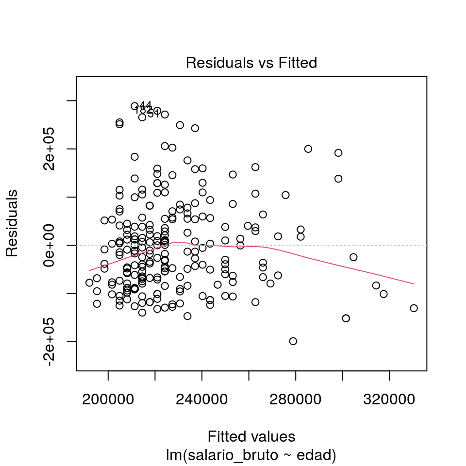

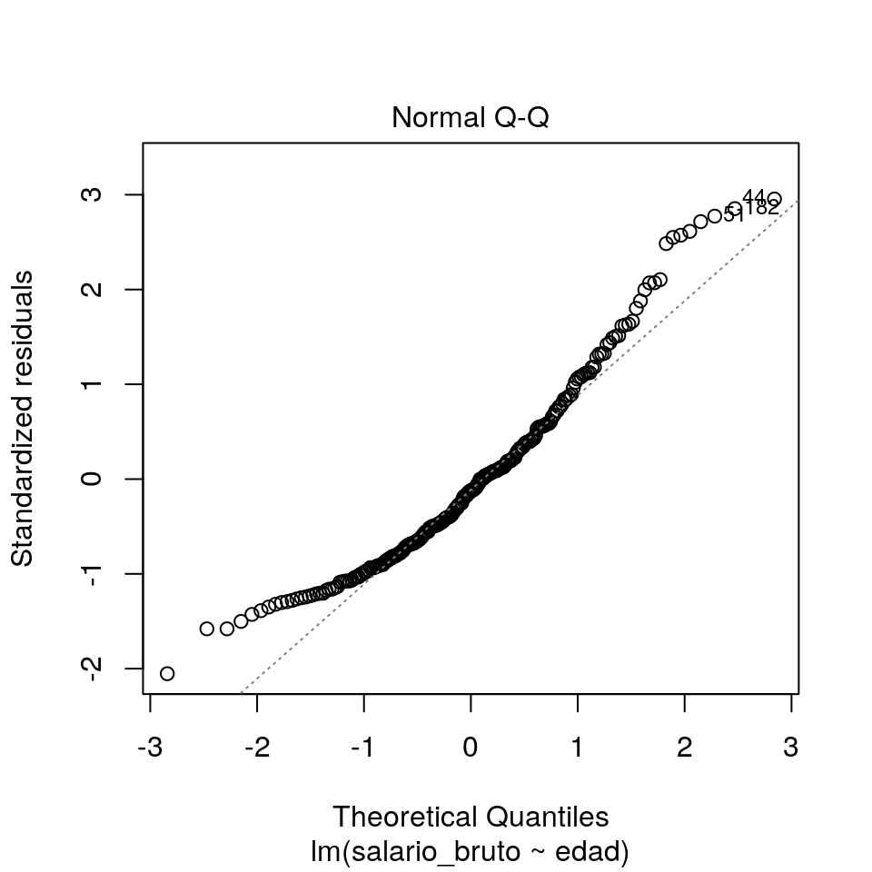

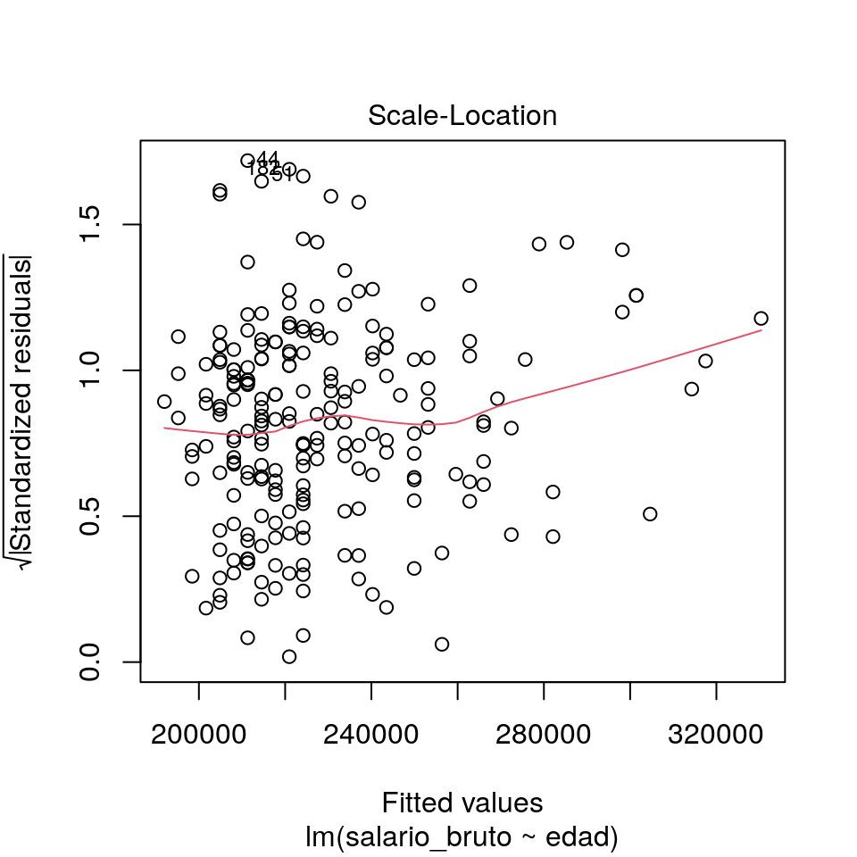

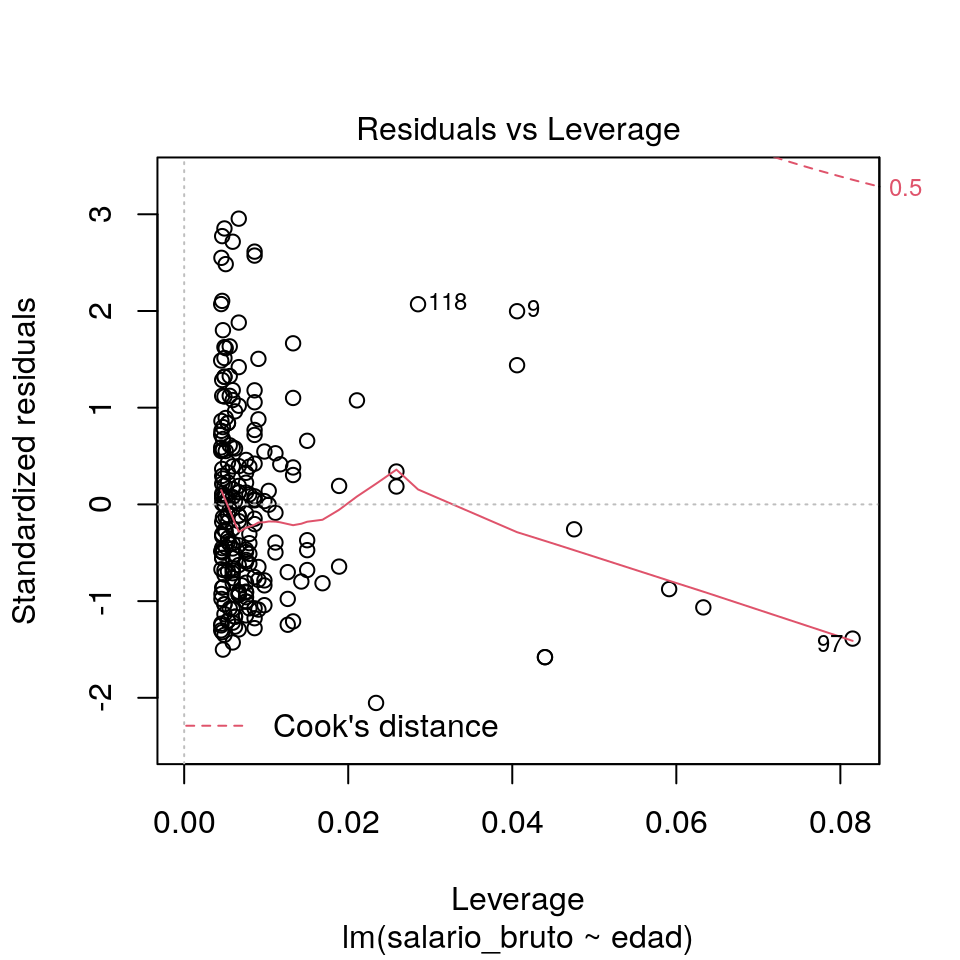

```r
plot(modelo_edad)
```

1. **Residuos** vs **valores predichos**: Parece existir cierta estructura en los datos dado que hay una curvatura
2. **Normal QQ plot**: los extremos no se ajustan a la distribución teórica
3. **Residual** vs **leverage**: Considerando el criterio que una observación es potencialmente influyente cuando $h_{ii}>0.5$ concluimos que no existen puntos que puedan ser consideradas influyentes. Sin embargo, observando la distribución de las observaciones se destaca la observación 97.

```r
#Miremos la observacion 97 en detalle
encuesta_sueldos[97,]
```

| edad | anos_de_experiencia | anos_en_la_empresa_actual | anos_en_el_puesto_actual | perfil | salario_bruto | salario_neto | id |
| --- | --- | --- | --- | --- | --- | --- | --- |
| 63 | 20 | 21 | 2 | BI Analyst / Data Analyst | 2e+05 | 140000 | 97 |

**Diagnóstico**: el modelo no cumple con los supuestos del modelo lineal. Parecen existir tres problemas situaciones: violación del supuesto de linealidad de la esperanza condicional, falta de normalidad y presencia de observaciones de alto leverage

**Modelo de experiencia**

Observemos estos gráficos para el modelo de experiencia

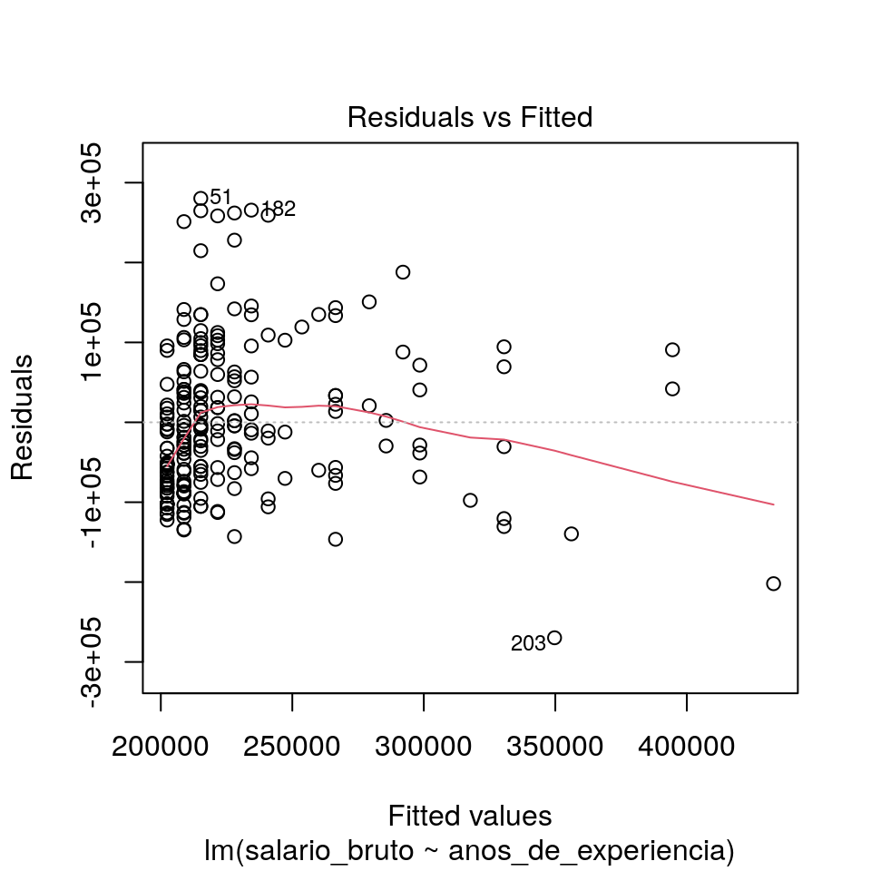

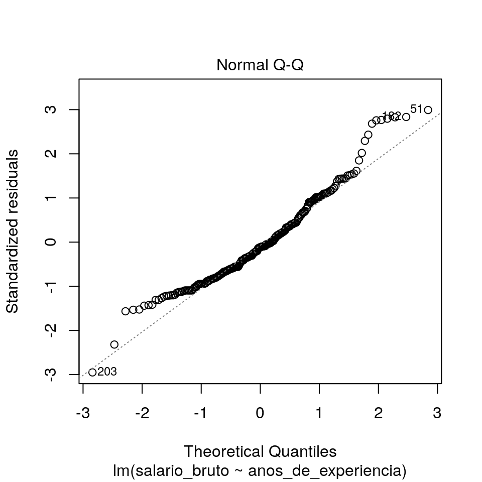

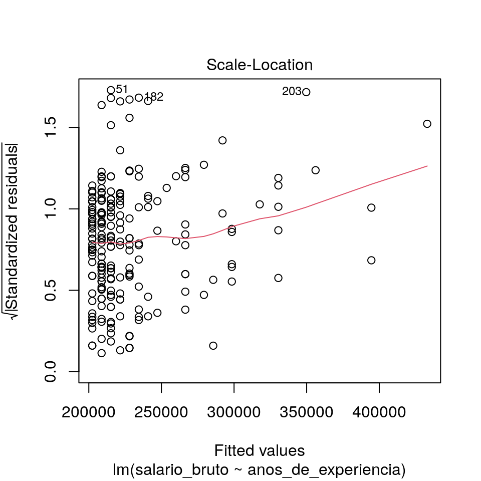

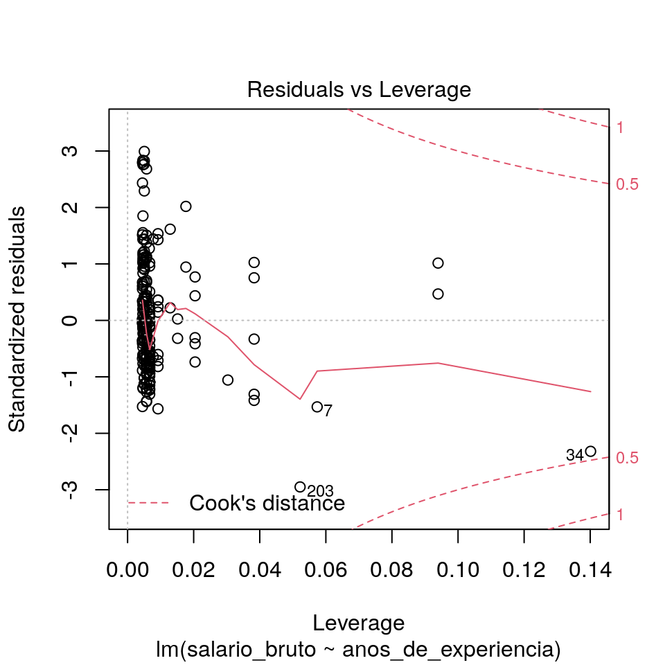

```r
plot(modelo_experiencia)
```

¿Qué observamos en este caso? ¿Qué diagnóstico darían?

### Broom: augment_columns

Con la función `augment_columns()` del paquete broom podemos agregar información a nuestro dataset original o a datos nuevos. Toma como argumentos: `x`: el modelo y `data`: nuestro dataset.

```r
# Agregamos las columnas
encuesta_aumentada = augment_columns(x=modelo_experiencia, data=encuesta_sueldos)
# Observamos los resultados
glimpse(encuesta_aumentada)
```

```
## Rows: 222
## Columns: 15
## $ edad                      <dbl> 27, 43, 25, 34, 23, 22, 59, 35, 53, 36, 25, …
## $ anos_de_experiencia       <dbl> 0, 0, 2, 3, 0, 0, 24, 7, 4, 12, 0, 2, 3, 1, …
## $ anos_en_la_empresa_actual <dbl> 0, 0, 1, 1, 0, 0, 24, 0, 2, 15, 0, 1, 0, 1, …
## $ anos_en_el_puesto_actual  <dbl> 0, 0, 1, 1, 0, 0, 14, 0, 2, 3, 0, 0, 0, 1, 0…
## $ perfil                    <chr> "Data Engineer", "BI Analyst / Data Analyst"…
## $ salario_bruto             <dbl> 95000, 220000, 160000, 324415, 100000, 16000…
## $ salario_neto              <dbl> 79000, 183000, 125000, 207575, 90000, 134000…
## $ id                        <int> 1, 2, 3, 4, 5, 6, 7, 8, 9, 10, 11, 12, 13, 1…
## $ .fitted                   <dbl> 202389.9, 202389.9, 215201.2, 221606.9, 2023…
## $ .se.fit                   <dbl> 7680.405, 7680.405, 6683.690, 6405.399, 7680…
## $ .resid                    <dbl> -107389.926, 17610.074, -55201.243, 102808.0…
## $ .hat                      <dbl> 0.006688503, 0.006688503, 0.005065161, 0.004…
## $ .sigma                    <dbl> 93843.81, 94118.28, 94051.54, 93867.93, 9386…
## $ .cooksd                   <dbl> 4.432164e-03, 1.191821e-04, 8.839596e-04, 2.…
## $ .std.resid                <dbl> -1.14736386, 0.18814765, -0.58929383, 1.0972…
```

La función agregó varias columnas al dataset:

- .fitted: es el valor predicho
- .resid: es el residuo
- .std.resid: es el residuo estandarizado

Al contar con esta información como dataframe podemos trabajarla de diversas maneras. Por ejemplo, podemos realizar los gráficos de diagnóstico con ggplot

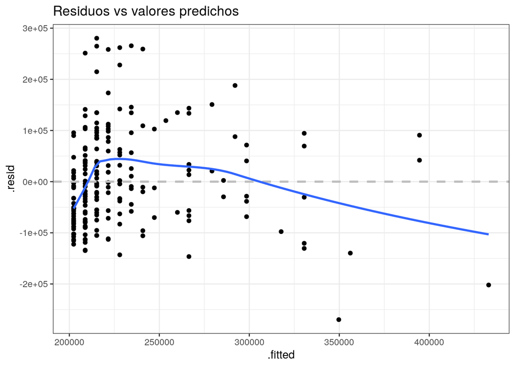

```r
ggplot(encuesta_aumentada, aes(.fitted, .resid)) +
  geom_point()+
  geom_hline(size = 1, colour = "grey", linetype="dashed", yintercept = 0) +
  geom_smooth(se = FALSE) +
  theme_bw() +
  labs(title = "Residuos vs valores predichos")
```

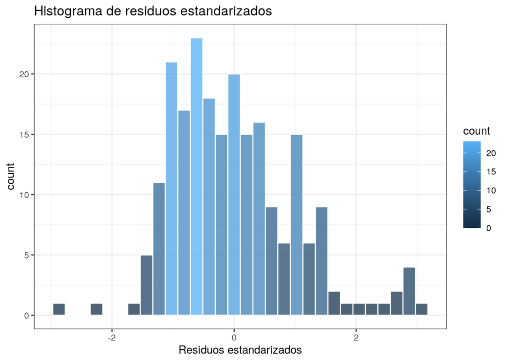

```r
ggplot(encuesta_aumentada, aes(x= .std.resid)) +
  geom_histogram(col = "white", aes( fill = ..count..), alpha = 0.75) +
  labs(title = "Histograma de residuos estandarizados") +
  labs(x = "Residuos estandarizados") +
  theme_bw()
```

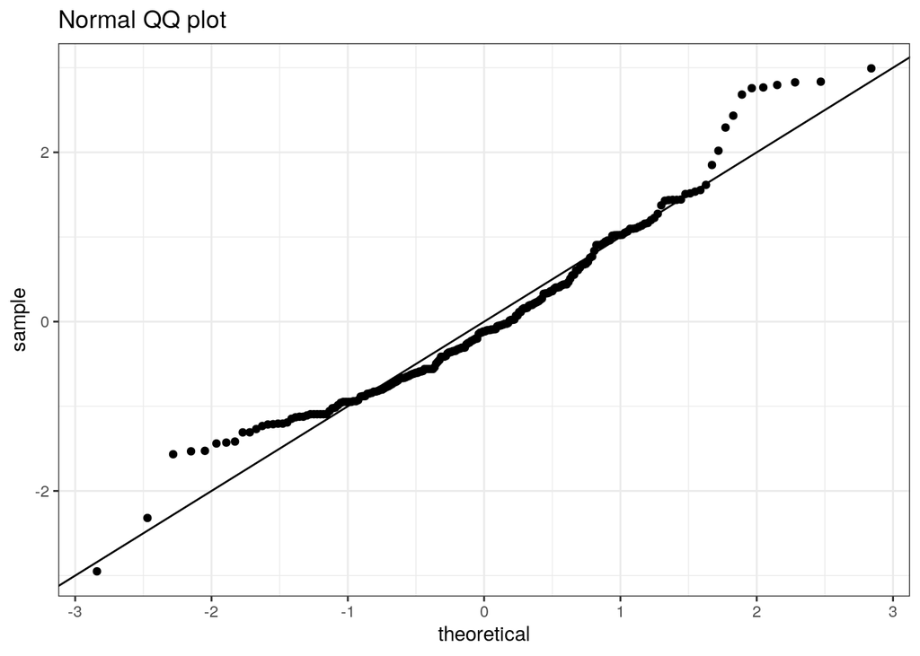

```r
ggplot(encuesta_aumentada, aes(sample= .std.resid))+
  stat_qq()+
  geom_abline() +
  theme_bw() +
  labs(title = "Normal QQ plot")
```

Para mayor detalle de cómo sería la distribución de los residuos según el tipo de QQ-plot, sugerimos ver los ejemplos en [Quantile-Quantile Plots](https://www.ucd.ie/ecomodel/Resources/QQplots_WebVersion.html#right-skewed-data).

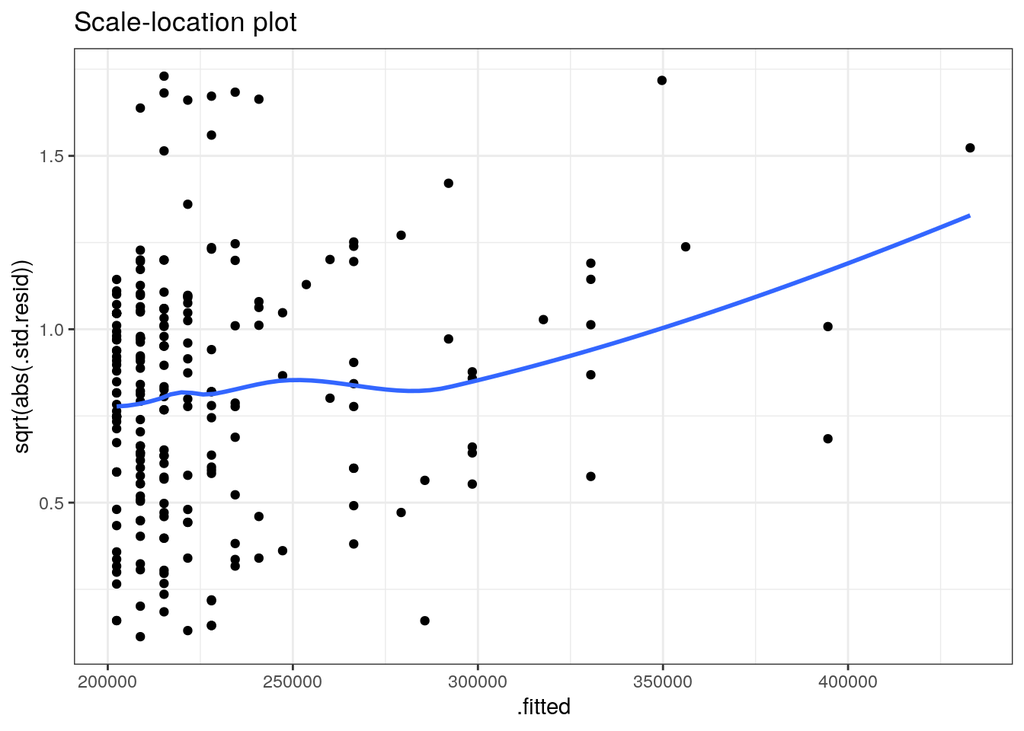

```r
ggplot(encuesta_aumentada, aes(.fitted, sqrt(abs(.std.resid))))+
  geom_point()+
  geom_smooth(se = FALSE) +
  theme_bw() +
  labs(title = "Scale-location plot")
```

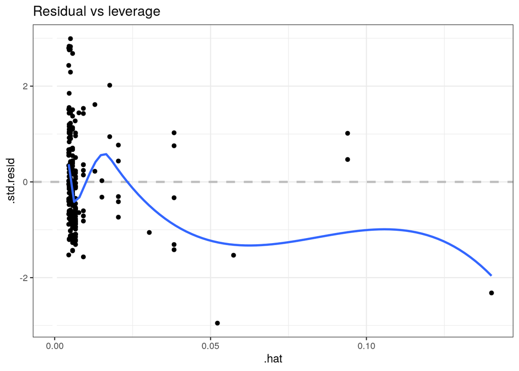

```r
ggplot(encuesta_aumentada, aes(.hat, .std.resid)) +
  geom_vline(size = 2, colour = "white", xintercept = 0) +
  geom_hline(size = 1, colour = "grey", linetype="dashed", yintercept = 0) +
  geom_point() + geom_smooth(se = FALSE) +
  theme_bw() +
  labs(title = "Residual vs leverage")
```

Dado que estamos trabajando con un modelo de regresión podemos observar este punto y la recta del modelo.

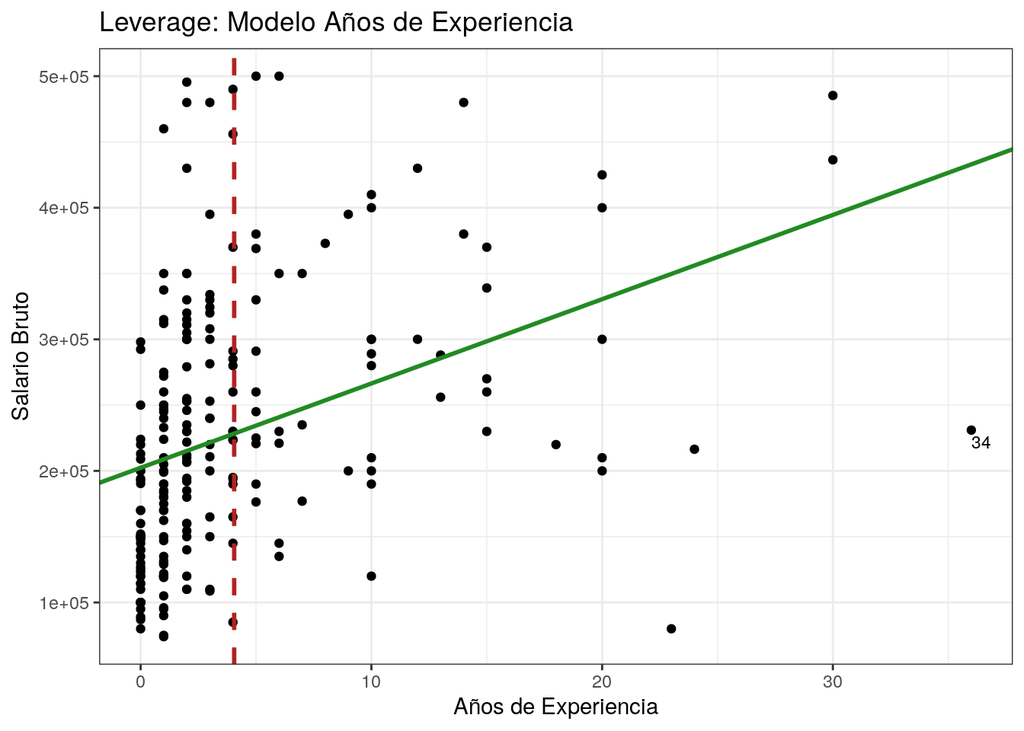

```r
ggplot(data=encuesta_aumentada, aes(x=anos_de_experiencia, y=salario_bruto)) +
  # Graficamos los puntos
  geom_point() +
  # Graficamos el modelo
  geom_abline(intercept = modelo_experiencia$coefficients[1], slope = modelo_experiencia$coefficients[2], color='forestgreen', size=1) +
  # Graficamos el promedio de la variable x
  geom_vline(xintercept = mean(encuesta_aumentada$anos_de_experiencia), color='firebrick', linetype='dashed', size=1) +
  # Etiquetamos el punto relevante
  geom_text(aes(label=ifelse(.hat>0.10 ,as.character(id),'')),hjust=0,vjust=1.4, size=3) +
  theme_bw() +
  labs(title = "Leverage: Modelo Años de Experiencia", x="Años de Experiencia", y="Salario Bruto")
```

Versiones anteriores de la notebook se pueden encontrar en:

[EEA-2021](https://eea-uba.github.io/EEA-2021/clase%204/Clase-4---Regresion-Lineal-Simple-Eval.html): Elaborada por Juan Manuel Barriola y Sofía Perini

[EEA-2020](https://eea-uba.github.io/EEA-2020/clase%204/Clase-4---Regresion-Lineal-Simple-Eval.html): Elaborada por Juan Manuel Barriola y Sofía Perini